# Midterm-Project-(NBA-Shot-Chart)

Brayden Fretland

2026-04-03

## Visualizationg of Timberwolves Shot Data Over Time

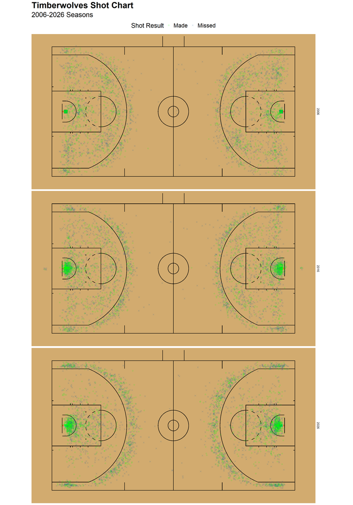

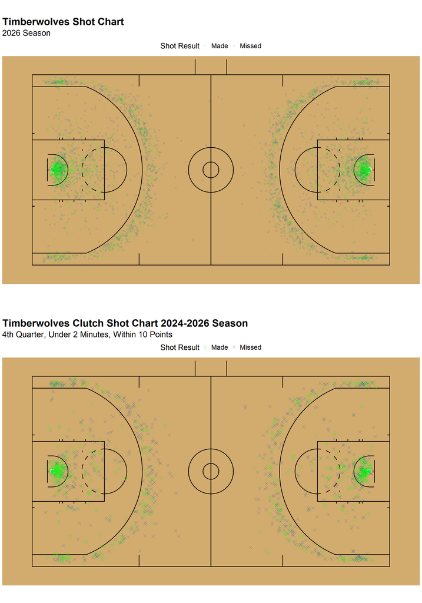

## Summary of the data visualization:

- The graphs display how the Timberwolves have moved away from shooting mid-range shots.
- Majority of shot attempts are located in the paint or behind the three point line.
- Corner three pointers attempts are more efficient than any other three point locations.
- Three point attempts are being shot from deeper distances more.
- The data visualizations indicate that shot selection is similar, but at a lower percentage during the clutch situations.

## Detailed explanation:

#### Increase in three point and paint shot attemps:

- With a decrease in mid-range attempts that leads to a larger increase in shot attempts elsewhere such as the paint or beyond the three point line.
- An increase in paint shot attempts correlated to analytics as you shot 55-60% in the paint, and at the mid range you shot on average 45%. Both are worth two points, so teams are realizing that shooting in the paint is more effective.
- For three pointers it follows similar analytics. The data shows there is a large similarity in shots made from the mid-range and beyond the three point line. Since the percentage of makes is similar, this leads to more three point attempts as the expected value of points increases.

#### Higher efficency in the corner:

- Although it is hard to notice in the data, corner three point attempts have a higher make rate than any other three point location. Analytics back this up as well as the average percent from the corner three is 40%, and any other three point shot is 36%.
- Part of the reason that the corner three pointer is a shorter distance at 22 feet, whereas any other three point shot is around 23.75 feet. This is due to the NBA not wanting to adjust the court dimensions when implementing and adjusting the three point line 1979 to make every three point attempt the same distance.
- The corner three point shot is also widely known for having a favorable shooting angle. This is due to depth perception, and the shooter being in line with the sideline and baseline.
- The corner three pointer is considered one of the most valuable shots in the game. This is due to the players making it at a higher percent than any other three point shot, it spaces out the offense to allow for effective strategies, and has a high expected value of points for each shot attempt.

#### Deeper three point attempts:

- The graphs show how from 2006 to 2016 there has been a large increase in three pointers attempted. Another noticeable trend from 2016 to 2026 is how much deeper the average three point attempt is being taken.
- The game of basketball will always be evolving, as many today see the three point shot being the most valuable shot in the game. With that being said more three pointers are being attempted and players are improving at shooting them, which leads to them extending their range even farther.
- This is partially due to modern NBA influences such as Curry, who is known for shooting a lot of threes and very deep threes.
- Although the expected value for points decreases the farther away from the basketball hoop you are, the expected value is still very high as a three pointer is more valuable than a two. A deep three point make will also lead to a lot of fan interaction and create a chaotic environment for the opposing team.
- Being able to shoot and make deeper threes allows for you to space out the court better for your offense and be more effective as a team.

#### Clutch Shots vs. Regular Shots:

- The clutch shot chart represents high-pressure situations where every shot matters and impacts the game as there is only two minutes left in a close game.
- While comparing the regular shot data and clutch shot data it is noticeable that the trend is the same by sticking with only three pointers and paint shots and a limited amount of mid-range shots.
- The graph for clutch shots show that the Timberwolves tend to not shot as well as normal as there is a larger amount of misses. This can be due to fatigue after playing all game, pressure and nerves affecting the players, and more intense defense being played.
- Another trend shown is an increase in the amount of three point attempts. One of the reasons for a large increase in three point attempts is due to threes being the fastest way to cut the lead while losing.
- Overall, the shot selection between clutch and regular situations is very similar. It shows the team still valuing the higher expected value shots, while the clutch time shooting at a slightly lower percent.